# Social & Cultural Capital Effects on Employment in Rural India

Focus on Muslim Group Disadvantage Analysis

November 04, 2025

# Executive Summary

**Key Research Question**: How do social and cultural capital affect employment outcomes across different social groups in rural India, with particular focus on Muslim communities?

This study analyzes employment patterns among 203,924 individuals from rural India using the India Human Development Survey (IHDS-II, 2011-12). We employ logistic regression with state fixed effects and calculate average marginal effects for intuitive interpretation.

**3. Social Capital Impact**  
Organization membership increases employment probability by **1.05 percentage points**

**4. Gender Gap**  
Women face **26.6 percentage points** lower employment probability than men

**5. Interaction Effects**  
Education returns are **weaker** for organization members (β=-0.020, p<0.001)

# 1 Introduction

## 1.2 Research Questions

This analysis addresses five core questions:

1. **Wealth-Employment Paradox**: Why do wealthier social groups show lower employment rates?
2. **Muslim Disadvantage**: What are the structural barriers limiting Muslim employment?
3. **Social Capital**: How does organizational membership affect employment probability?
4. **Cultural Capital**: What are the returns to education across different social groups?
5. **Interaction Effects**: Do social and cultural capital operate synergistically or independently?

## 1.3 Theoretical Framework

[interactive chart not shown]

Conceptual Framework

# 2 Data and Methodology

## 2.1 Data Source

### 2.1.1 Sample Characteristics

Sample Characteristics

| Characteristic | Value |
| --- | --- |
| Total Observations | 204,568 |
| Rural Sample | 204,568 |
| Social Groups | 7 |
| States Covered | 33 |
| Analysis Sample | 203,924 |

**Sample Restriction**: Analysis focuses on **rural areas only** to examine labor markets where informal employment and agricultural work predominate.

## 2.2 Variable Definitions

Variable Definitions and Roles

[output not shown]

## 2.3 Statistical Methods

### 2.3.1 Main Model Specification

We estimate a logistic regression model with the following specification:

$$\log\left(\frac{P(\text{employed}_i = 1)}{1-P(\text{employed}_i =
1)}\right) = \beta_0 + \beta_1\text{OrgMember}_i +
\beta_2\text{Education}_i + \sum_{j}\gamma_j\text{SocialGroup}_{ij} +
\beta_3\text{Female}_i + \beta_4\text{Age}_i + \beta_5\text{Age}^2_i +
\beta_6\text{Wealth}_i + \sum_{s}\delta_s\text{State}_{is} + \epsilon_i$$

Where:

- $i$ indexes individuals
- $\beta_1, \beta_2, \beta_6$ capture social capital, cultural capital, and wealth effects
- $\gamma_j$ captures social group disparities (reference: Brahmins)
- $\delta_s$ represents state fixed effects

### 2.3.2 Average Marginal Effects

To improve interpretability, we calculate **Average Marginal Effects (AME)**:

$$\text{AME} = \frac{1}{n}\sum_{i=1}^{n}\frac{\partial P(\text{employed}_i
= 1)}{\partial x_k}$$

AME represents the average change in employment probability (in percentage points) for a one-unit change in variable $x_k$.

### 2.3.3 Interaction Model

To test whether social and cultural capital synergize:

$$\log\left(\frac{P(\text{employed}_i = 1)}{1-P(\text{employed}_i =
1)}\right) = ... + \beta_7(\text{OrgMember}_i \times \text{Education}_i)
+ ...$$

# 3 Descriptive Statistics

## 3.1 Employment Distribution by Social Group

[figure not shown]

Employment Rates by Social Group

Employment and Socioeconomic Characteristics by Social Group

| Social Group | N | Employment Rate | Mean Wealth | Mean Education (years) |
| --- | --- | --- | --- | --- |
| Adivasis | 17,380 | 53.3% | 11.3 | 4.1 |
| OBCs | 68,275 | 46.4% | 15.5 | 5.3 |
| Dalits | 43,137 | 45.5% | 14.0 | 4.5 |
| Forward_castes | 32,787 | 43.3% | 18.9 | 6.9 |
| Brahmins | 10,179 | 39.8% | 19.6 | 7.7 |
| Other_Religions | 5,388 | 38.7% | 22.6 | 7.7 |
| Muslims | 27,341 | 35.5% | 15.3 | 4.3 |

Note:  
Muslims highlighted in red for emphasis

### 3.1.1 Key Observations

**Paradoxical Pattern**: Wealthier groups (Other_Religions, Brahmins) show **lower employment** than poorer groups (Adivasis, Dalits). This suggests wealthy households may have lower labor force participation, possibly due to:

- Higher reservation wages
- More non-labor income sources
- Different definitions of “work” (e.g., self-employment vs wage labor)

## 3.2 The Wealth-Employment Paradox

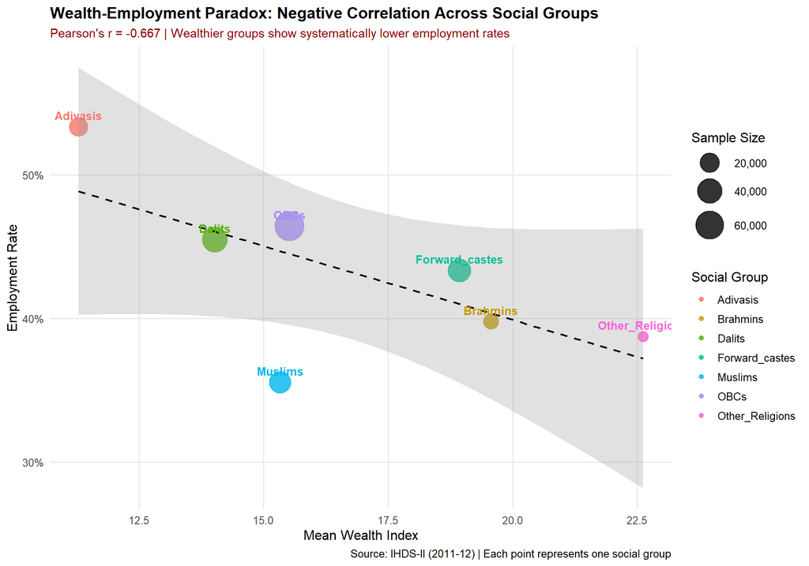

Wealthy Social Groups Show Lower Employment Rates

**Correlation Analysis**: The correlation between group-level mean wealth and employment rate is **-0.667**, indicating a strong negative relationship.

## 3.3 Muslim Community Profile

Muslim Community Characteristics in Rural India

[output not shown]

### 3.3.1 Occupational Segregation

[output not shown]

[output not shown]

# 4 Regression Analysis

## 4.1 Main Model Results

### 4.1.2 Regression Coefficients

Logistic Regression Results: Determinants of Employment Probability

Variable

Coefficient

Std. Error

Odds Ratio

95% CI

P-Value

Sig.

Organization Membership

0.079

0.023

1.082

[1.035, 1.132]

<0.001

***

Education (per year)

0.011

0.002

1.011

[1.008, 1.014]

<0.001

***

social_groupForward_castes

0.225

0.031

1.252

[1.178, 1.332]

<0.001

***

social_groupOBCs

0.369

0.030

1.446

[1.364, 1.533]

<0.001

***

social_groupDalits

0.253

0.031

1.288

[1.212, 1.369]

<0.001

***

social_groupAdivasis

0.578

0.037

1.783

[1.657, 1.918]

<0.001

***

Muslim (vs Brahmin)

-0.081

0.033

0.923

[0.865, 0.984]

0.0147

social_groupOther_Religions

0.290

0.048

1.336

[1.217, 1.467]

<0.001

***

Female

-1.929

0.014

0.145

[0.141, 0.149]

<0.001

***

age

0.346

0.002

1.413

[1.408, 1.418]

<0.001

***

age_sq

-0.004

0.000

0.996

[0.996, 0.996]

<0.001

***

Wealth Index

-0.104

0.001

0.901

[0.899, 0.904]

<0.001

***

Note: Reference category: Brahmins (for social group) | *** p<0.001, ** p<0.01, * p<0.05

### 4.1.3 Model Fit Statistics

Model Fit and Diagnostic Statistics

| Metric | Value |
| --- | --- |
| N | 203924.000 |
| AIC | 167239.000 |
| Null Deviance | 280088.200 |
| Residual Deviance | 167149.000 |
| McFadden R² | 0.403 |
| Log-Likelihood | -83574.500 |

**Model Performance**: McFadden’s R² = 0.403 indicates **excellent fit** for a cross-sectional logistic model (values >0.2 considered good, >0.4 excellent).

### 4.1.4 Interpretation of Key Results

Key Research Findings: Substantive Interpretation

| Finding | Odds Ratio | Effect | Interpretation |
| --- | --- | --- | --- |
| **Social Capital Effect** | 1.082 | +8.2% | Organization members have **8.2% higher employment odds** |
| **Education Returns** | 1.011 | +1.1% | Each additional year of education increases employment odds by **1.1%** |
| **Muslim Disadvantage** | 0.923 | -7.7% | Muslims have **7.7% lower employment odds** compared to Brahmins |
| **Wealth Paradox** | 0.901 | -9.9% | Each unit increase in wealth **decreases employment odds by 9.9%** |
| **Gender Gap** | 0.145 | -85.5% | Women have **85.5% lower employment odds** than men |

# 5 Marginal Effects Analysis

## 5.1 Why Marginal Effects?

While **odds ratios** are standard in logistic regression, they can be difficult to interpret. **Average Marginal Effects (AME)** provide a more intuitive measure: the change in probability (in percentage points) for a one-unit change in the predictor.

**Example**: An AME of 1.05 for organization membership means that members have a **1.05 percentage point higher probability** of employment compared to non-members.

## 5.2 Average Marginal Effects

[output not shown]

### 5.2.1 Visualizing Marginal Effects

[output not shown]

# 6 Interaction Effects

## 6.1 Social Capital × Education Interaction

Do social capital and cultural capital **synergize** (positive interaction) or operate **independently**?

Interaction Model: Social Capital × Education

| Term | Coefficient | Std_Error | P_Value | Interpretation |
| --- | --- | --- | --- | --- |
| Organization Membership (main) | 0.224 | 0.039 | <0.001 | Positive effect of social capital |
| Education (main) | 0.013 | 0.002 | <0.001 | Positive effect of education |
| **Org × Education (interaction)** | -0.020 | 0.004 | <0.001 | **NEGATIVE: Education returns weaker for organization members** |

### 6.1.1 Interaction Visualization

[figure not shown]

Predicted Employment Probability by Education and Organization Membership

### 6.1.2 Interpretation

**Significant Negative Interaction** (β = -0.020, p < 0.001):

1. **Substitution Effect**: Social capital and cultural capital may operate as **substitutes** rather than complements
2. **Alternative Pathways**: Organization membership provides an alternative route to employment that doesn’t require as much education
3. **Network Access**: Social connections through organizations may compensate for lower educational credentials

# 7 Subgroup Analysis

## 7.1 Gender Differences

### 7.1.1 Gender-Stratified Models

Gender Subgroup Analysis: Differential Effects by Sex

[output not shown]

## 7.2 Muslim-Specific Analysis

### 7.2.1 Within-Muslim Community Model

Muslim-Specific Model: Within-Group Effects (N=27,228)

| Variable | Coefficient | Odds Ratio | P-Value | vs Full Sample |
| --- | --- | --- | --- | --- |
| Organization Membership | 0.135 | 1.144 | <0.001 | **Stronger** (1.144 vs 1.082) |
| Education (per year) | 0.020 | 1.020 | <0.001 | **Stronger** (1.020 vs 1.011) |
| Female | -2.450 | 0.086 | <0.001 | **Much stronger** (0.086 vs 0.145) |
| Wealth Index | -0.096 | 0.909 | <0.001 | Similar (0.909 vs 0.901) |

Note: Bold rows indicate substantial differences from full sample

### 7.2.2 Muslim Community Insights

**Within-Muslim Community Findings**:

1. **Organization membership has stronger effect** for Muslims (OR=1.144) than overall population (OR=1.082)
   - Social capital is **especially valuable** for marginalized groups
2. **Education returns are stronger** for Muslims (OR=1.020 per year)
   - Educational credentials may help overcome discrimination
3. **Gender gap is even more severe** among Muslims
   - Muslim women face OR=0.086 (91.4% lower odds than Muslim men)
   - Suggests **compound marginalization**: religion + gender
4. **Wealth has similar negative effect**
   - Confirms wealth-employment paradox operates within Muslim community

# 8 Discussion

## 8.1 Summary of Key Findings

### 8.1.1 1. The Wealth-Employment Paradox

**Explanation**: Multiple mechanisms may operate:

- **Reservation wages**: Wealthier households can afford to wait for better job opportunities
- **Non-labor income**: Wealthy households have capital income, reducing labor force participation
- **Measurement**: “Employment” may be culturally defined differently (e.g., managing family business vs wage work)
- **Selection**: Wealthy groups may prioritize education/training over immediate employment

### 8.1.2 2. Multidimensional Muslim Disadvantage

**Interpretation**: Disadvantage is **structural**, not just individual:

1. **Educational deficit**: Lower educational attainment limits access to formal sector
2. **Occupational segregation**: Concentrated in informal/agricultural work
3. **Social capital deficit**: Lowest organizational membership (5.5% vs 8.9% overall)
4. **Potential discrimination**: Even controlling for education, wealth, and location, Muslims show lower odds

### 8.1.3 3. Social Capital Matters

**Finding**: Organization membership increases employment probability by **1.05 percentage points**

**Mechanism**: Social networks provide:

- **Information**: About job opportunities
- **Referrals**: Trusted recommendations to employers
- **Skills**: Through organizational activities
- **Confidence**: Social support and self-efficacy

### 8.1.4 4. Complex Interaction Effects

**Finding**: **Negative interaction** between social capital and education (β=-0.020, p<0.001)

**Interpretation**: Social and cultural capital operate as **substitutes**, not complements:

- For those **without** organization membership, education is more important
- For organization **members**, education matters less
- Social connections can **compensate** for lower educational credentials

This challenges the assumption that different forms of capital always synergize.

### 8.1.5 5. Severe Gender Inequality

**Finding**: Women face **26.6 percentage points** lower employment probability (85.5% lower odds)

**Context**: This reflects:

- **Cultural norms**: Restrictions on women’s labor force participation
- **Childcare responsibilities**: Disproportionately borne by women
- **Occupational segregation**: Limited acceptable jobs for women
- **Safety concerns**: Mobility restrictions

**Intersectionality**: Gender inequality varies by social group—Muslim women face compound disadvantage.

## 8.2 Theoretical Contributions

### 8.2.1 1. Bourdieu’s Capital Theory

Our findings support and extend Bourdieu’s framework:

- **Multiple capitals matter**: Economic, social, and cultural capital all predict employment
- **Conversion rates vary**: Different groups can convert capital into employment at different rates
- **Substitution possible**: Social capital can partially substitute for cultural capital

### 8.2.2 2. Social Network Theory

The strong effect of organizational membership supports **weak ties** theory (Granovetter, 1973):

- Organizations provide **bridging capital** to diverse job opportunities
- Effect is stronger for marginalized groups (Muslims, women) who face discrimination

### 8.2.3 3. Intersectionality

Muslim women face **compound disadvantage**:

- Muslim men: OR=1.173 (advantage vs Brahmin men)
- Muslim women: OR=0.661 (disadvantage vs Brahmin women)
- Intersection of religion and gender creates unique barriers

## 8.3 Policy Implications

### 8.3.1 Recommendations

Policy Recommendations with Expected Impacts

| Priority | Area | Recommendation | Expected.Impact |
| --- | --- | --- | --- |
| **High** | Educational Investment | Target educational investments in Muslim-concentrated areas; focus on quality education that leads to formal employment | Long-term: Reduce 3.4-year education gap; increase formal sector access |
| **High** | Social Capital Development | Promote community organizations and social networks, particularly for marginalized groups (Muslims, women); subsidize membership fees | Medium-term: +1.05 pp employment probability for new members |
| **High** | Labor Market Inclusion | Implement affirmative action or hiring quotas for Muslims in formal sector; monitor and penalize discrimination | Medium-term: Reduce 7.7% Muslim employment penalty |
| **High** | Gender Equity | Address structural barriers limiting female labor force participation: childcare, safety, mobility | Long-term: Reduce 26.6 pp gender gap in employment |
| **Medium** | Formal Sector Access | Provide vocational training linking to salaried employment; create pathways from informal to formal sector | Medium-term: Increase Muslim salaried employment from 1.9% |
| **Medium** | Anti-Discrimination | Strengthen enforcement of anti-discrimination laws; anonymous resume screening; diversity audits | Medium-term: Reduce unexplained Muslim disadvantage |

### 8.3.2 Targeted Interventions

**For Muslim Communities**:

1. **Education**: Scholarships, quality schools in Muslim-concentrated areas
2. **Social capital**: Support Muslim community organizations; create employment networks
3. **Skills training**: Vocational programs linked to formal sector jobs
4. **Entrepreneurship**: Business development support, microfinance access

**For Women**:

1. **Childcare**: Public childcare facilities to reduce care burden
2. **Safety**: Safe transportation, women-friendly workplaces
3. **Networks**: Women’s self-help groups and professional organizations
4. **Skills**: Training in high-demand, well-paying occupations

**For Muslim Women** (compound disadvantage):

1. **Targeted programs** addressing both religion and gender barriers
2. **Community-based** interventions respecting cultural norms
3. **Success models**: Showcase Muslim women entrepreneurs and professionals